# COMP7404 Assignment 4

In this assignment you will implement the supervised classifiers of chapters 4 and 5. This assignment is based on work by Li-Yi Wei et al. and our textbook Python Machine Learning.

# Submission

Submit a single uid.ipynb file to moodle before the deadline. Ensure your file can be executed on Google Colab.

# Hand-written Digit Classification

In class we applied different scikit-learn classifers for the Iris data set.

In this assignment, we will apply the same set of classifiers over a different data set: hand-written digits. Please write down the code for different classifiers, choose their hyper-parameters using a validation set, and compare their performance via an accuracy score on a test set. Add sections for a discussions of results. Which classifier(s) perform(s) the best and worst, and why?

The classifiers include:

- perceptron
- logistic regression
- SVM
- decision tree
- random forest
- KNN

The dataset is available as part of scikit learn, as follows.

## Load data

```python
from sklearn.datasets import load_digits
digits = load_digits()

X = digits.data # training data
y = digits.target # training label

print(X.shape)
print(y.shape)
```

```
(1797, 64)
(1797,)
```

## Visualize data

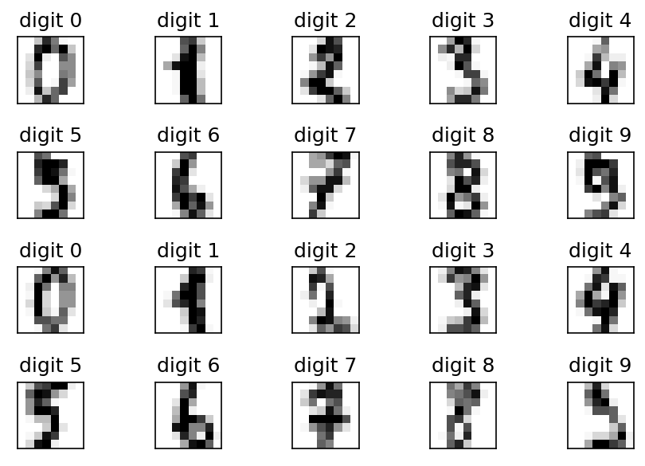

```python
import matplotlib.pyplot as plt
import pylab as pl
import matplotlib as mpl
mpl.rcParams['figure.dpi'] = 150
num_rows = 4
num_cols = 5
fig, ax = plt.subplots(nrows=num_rows, ncols=num_cols, sharex=True, sharey=True)
ax = ax.flatten()
for index in range(num_rows*num_cols):
    img = digits.images[index]
    label = digits.target[index]
    ax[index].imshow(img, cmap='Greys', interpolation='nearest')
    ax[index].set_title('digit ' + str(label))
ax[0].set_xticks([])
ax[0].set_yticks([])
plt.tight_layout()
plt.show()
```

## Date Preprocessing

Hint: Divide training and test data set and apply other techinques we have learned if needed.

```python
#Your code comes here

from sklearn.model_selection import train_test_split
from sklearn.preprocessing import StandardScaler

# Feature scaling
X_train, X_test, y_train, y_test = train_test_split(X, y, test_size=0.3, random_state=1, stratify=y)

from sklearn.preprocessing import StandardScaler
sc = StandardScaler()
sc.fit(X_train)
X_train_std = sc.transform(X_train)
X_test_std = sc.transform(X_test)

print(X_train_std.shape, X_test_std.shape)
print(y_train.shape, y_test.shape)

#from the shape, we can get 64 weights needed.
#for every sample, 64 X input and a Y output.
```

```
(1257, 64) (540, 64)
(1257,) (540,)
```

```python
X_train_std[3]
```

```
array([ 0.        , -0.34757812, -0.25748923,  0.30877893,  0.50912284,
       -0.67219995, -0.42429148, -0.13159718, -0.06568468, -0.62509124,
        0.84159358, -0.48479412,  0.15550287,  0.30880143, -0.52249404,
       -0.14001158, -0.04610817,  0.10972986,  0.90845135, -0.87366972,
        0.78571628, -0.279583  , -0.55919536, -0.12478935, -0.03992024,
       -0.78342472, -0.97584143, -0.15113557,  0.99727222, -0.08422225,
       -0.64044306, -0.0489116 ,  0.        , -0.66587775, -1.21630238,
       -0.79544103, -0.20091269,  1.23544738, -0.2773963 ,  0.        ,
       -0.06972296, -0.52935807,  0.47531502, -0.65601923, -1.21941264,
        0.85524355,  0.56021369, -0.0826178 , -0.04237744, -0.40053557,
        1.54233277, -0.85085911, -0.45435063,  1.18874704, -0.16358151,
       -0.21652774, -0.02821663, -0.31435062,  0.27898147,  0.23025624,
        0.23751132,  0.20343818, -0.51013604, -0.18192724])
```

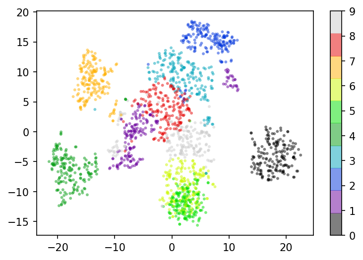

```python
# using TSNE to analyze the structure of the dataset

from sklearn.manifold import TSNE
X2d = TSNE(n_components=3, init='random', random_state=0).fit_transform(X, y)
plt.scatter(X2d[:, 0], X2d[:, 1], c=y, s=8, edgecolor='none', alpha=0.5, cmap=plt.cm.get_cmap('nipy_spectral', 10))
plt.colorbar()
plt.show()

# 0,4,7 can easily classify.
```

## Classifier #1 Perceptron

```python
#Your code, including traing and testing, to observe the accuracies.

from sklearn.model_selection import GridSearchCV
from sklearn.linear_model import Perceptron
from sklearn.metrics import accuracy_score


estimator = Perceptron(max_iter=40, random_state=0)
parameters = {'tol': [0.001, 0.01, 0.1], 'eta0': [0.001, 0.01, 0.1, 1]}
clf = GridSearchCV(estimator, parameters, cv=5, scoring='accuracy', iid=False)
clf.fit(X_train_std, y_train)
#choose the best hyper-parameter for training the model
clf.best_estimator_
```

```
Perceptron(alpha=0.0001, class_weight=None, early_stopping=False, eta0=1,
           fit_intercept=True, max_iter=40, n_iter_no_change=5, n_jobs=None,
           penalty=None, random_state=0, shuffle=True, tol=0.001,
           validation_fraction=0.1, verbose=0, warm_start=False)
```

```python
# model training and testing.

ppn = Perceptron(alpha=0.0001, class_weight=None, early_stopping=False, eta0=1,
           fit_intercept=True, max_iter=40, n_iter_no_change=5, n_jobs=None,
           penalty=None, random_state=0, shuffle=True, tol=0.001,
           validation_fraction=0.1, verbose=0, warm_start=False)
ppn.fit(X_train_std, y_train)
y_pred = ppn.predict(X_train_std)
print('Misclassified training samples:',(y_train!=y_pred).sum())
y_pred = ppn.predict(X_test_std)
print('Misclassified samples:', (y_test != y_pred).sum())
print('Accuracy for training sample: %.2f' % accuracy_score(y_train, ppn.predict(X_train_std)))
print('Accuracy for testing sample: %.2f' % accuracy_score(y_test, y_pred))
print('Alternative way for Accuracy for testing sample: %.2f' % ppn.score(X_test_std, y_test)) #Alternative method
```

```
Misclassified training samples: 28
Misclassified samples: 30
Accuracy for training sample: 0.98
Accuracy for testing sample: 0.94
Alternative way for Accuracy for testing sample: 0.94
```

## Classifier #2 Logistic Regression

```python
#Your code, including traing and testing, to observe the accuracies.

from sklearn.linear_model import LogisticRegression

estimator = LogisticRegression(solver='liblinear', multi_class='ovr')
parameters = {'C': [0.1, 0.5, 1.0], 'tol': [0.0001, 0.001, 0.1, 1.0]}
clf = GridSearchCV(estimator, parameters, cv=5, scoring='accuracy', iid=False)
clf.fit(X_train_std, y_train)
clf.best_estimator_
```

```
LogisticRegression(C=1.0, class_weight=None, dual=False, fit_intercept=True,
                   intercept_scaling=1, l1_ratio=None, max_iter=100,
                   multi_class='ovr', n_jobs=None, penalty='l2',
                   random_state=None, solver='liblinear', tol=0.0001, verbose=0,
                   warm_start=False)
```

```python
lr = LogisticRegression(C=1.0, class_weight=None, dual=False, fit_intercept=True,
                        intercept_scaling=1, l1_ratio=None, max_iter=100,
                        multi_class='ovr', n_jobs=None, penalty='l2',
                        random_state=None, solver='liblinear', tol=0.0001, verbose=0,
                        warm_start=False)
lr.fit(X_train_std, y_train)
print('Misclassified training samples:',(y_train!=lr.predict(X_train_std)).sum())
print('Misclassified samples:', (y_test != lr.predict(X_test_std)).sum())
print('Accuracy of training: %.3f' % accuracy_score(y_train, lr.predict(X_train_std)))
print('Accuracy of testing: %.3f' % accuracy_score(y_test, lr.predict(X_test_std)))
```

```
Misclassified training samples: 15
Misclassified samples: 20
Accuracy of training: 0.988
Accuracy of testing: 0.963
```

## Classifier #3 SVM

```python
#Your code, including traing and testing, to observe the accuracies.

# from the plot before, we can clearly see that the regression kernel is not linear.
# WE consider to use higher older function.

from sklearn.svm import LinearSVC, SVC
estimator = SVC(gamma='auto', max_iter=1000, random_state=1)
parameters = {'C': [0.1, 0.5, 1.0], 'kernel': ['poly', 'rbf', 'sigmoid']}
clf = GridSearchCV(estimator, parameters, cv=5, scoring='accuracy', iid=False)
clf.fit(X_train_std, y_train)
clf.best_estimator_
```

```
SVC(C=1.0, cache_size=200, class_weight=None, coef0=0.0,
    decision_function_shape='ovr', degree=3, gamma='auto', kernel='rbf',
    max_iter=1000, probability=False, random_state=1, shrinking=True, tol=0.001,
    verbose=False)
```

```python
# SVM model training and testing.

svm = SVC(C=1.0, cache_size=200, class_weight=None, coef0=0.0,
          decision_function_shape='ovr', degree=3, gamma='auto', kernel='rbf',
          max_iter=1000, probability=False, random_state=1, shrinking=True, tol=0.001,
          verbose=False)
svm.fit(X_train_std, y_train)
print('Misclassified training samples:',(y_train!=svm.predict(X_train_std)).sum())
print('Misclassified samples:', (y_test != svm.predict(X_test_std)).sum())
print('Training accuracy: %.3f' % accuracy_score(y_train, svm.predict(X_train_std)))
print('Testing accuracy: %.3f' % accuracy_score(y_test, svm.predict(X_test_std)))
```

```
Misclassified training samples: 3
Misclassified samples: 7
Training accuracy: 0.998
Testing accuracy: 0.987
```

## Classifier #4 Decision Tree

```python
#Your code, including traing and testing, to observe the accuracies.

from sklearn.tree import DecisionTreeClassifier
estimator = DecisionTreeClassifier(random_state=1)
parameters = {'criterion': ['gini', 'entropy'], 'max_depth': [5, 10, 15, 20]}
clf = GridSearchCV(estimator, parameters, cv=5, scoring='accuracy', iid=False)
clf.fit(X_train_std, y_train)
clf.best_estimator_
```

```
DecisionTreeClassifier(class_weight=None, criterion='entropy', max_depth=10,
                       max_features=None, max_leaf_nodes=None,
                       min_impurity_decrease=0.0, min_impurity_split=None,
                       min_samples_leaf=1, min_samples_split=2,
                       min_weight_fraction_leaf=0.0, presort=False,
                       random_state=1, splitter='best')
```

```python
# Decision tree model training and testing.
tree = DecisionTreeClassifier(class_weight=None, criterion='entropy', max_depth=10,
                              max_features=None, max_leaf_nodes=None,
                              min_impurity_decrease=0.0, min_impurity_split=None,
                              min_samples_leaf=1, min_samples_split=2,
                              min_weight_fraction_leaf=0.0, presort=False,
                              random_state=1, splitter='best')
tree.fit(X_train_std, y_train)
print('Misclassified training samples:',(y_train!=tree.predict(X_train_std)).sum())
print('Misclassified samples:', (y_test != tree.predict(X_test_std)).sum())
print('Training accuracy: %.3f' % accuracy_score(y_train, tree.predict(X_train_std)))
print('Testing accuracy: %.3f' % accuracy_score(y_test, tree.predict(X_test_std)))
```

```
Misclassified training samples: 1
Misclassified samples: 65
Training accuracy: 0.999
Testing accuracy: 0.880
```

## Classifer #5 Random Forest

```python
#Your code, including traing and testing, to observe the accuracies.

from sklearn.ensemble import RandomForestClassifier
estimator = RandomForestClassifier(max_depth=10, random_state=1)
parameters = {'criterion': ['gini', 'entropy'], 'n_estimators': [50, 100, 150]}
clf = GridSearchCV(estimator, parameters, cv=5, scoring='accuracy', iid=False)
clf.fit(X_train_std, y_train)
clf.best_estimator_
```

```
RandomForestClassifier(bootstrap=True, class_weight=None, criterion='entropy',
                       max_depth=10, max_features='auto', max_leaf_nodes=None,
                       min_impurity_decrease=0.0, min_impurity_split=None,
                       min_samples_leaf=1, min_samples_split=2,
                       min_weight_fraction_leaf=0.0, n_estimators=100,
                       n_jobs=None, oob_score=False, random_state=1, verbose=0,
                       warm_start=False)
```

```python
# Random forest model training and modelling

forest = RandomForestClassifier(bootstrap=True, class_weight=None, criterion='entropy',
                                max_depth=10, max_features='auto', max_leaf_nodes=None,
                                min_impurity_decrease=0.0, min_impurity_split=None,
                                min_samples_leaf=1, min_samples_split=2,
                                min_weight_fraction_leaf=0.0, n_estimators=100,
                                n_jobs=None, oob_score=False, random_state=1, verbose=0,
                                warm_start=False)
forest.fit(X_train_std, y_train)
print('Misclassified training samples:',(y_train!=forest.predict(X_train_std)).sum())
print('Misclassified samples:', (y_test != forest.predict(X_test_std)).sum())
print('Training accuracy: %.3f' % accuracy_score(y_train, forest.predict(X_train_std)))
print('Testing accuracy: %.3f' % accuracy_score(y_test, forest.predict(X_test_std)))
```

```
Misclassified training samples: 0
Misclassified samples: 17
Training accuracy: 1.000
Testing accuracy: 0.969
```

## Classifier #6 KNN

```python
#Your code, including traing and testing, to observe the accuracies.


from sklearn.neighbors import KNeighborsClassifier
estimator = KNeighborsClassifier(p=2, metric='minkowski')
parameters = {'n_neighbors': [3, 4, 5, 7, 9]}
clf = GridSearchCV(estimator, parameters, cv=5, scoring='accuracy', iid=False)
clf.fit(X_train_std, y_train)
clf.best_estimator_
```

```
KNeighborsClassifier(algorithm='auto', leaf_size=30, metric='minkowski',
                     metric_params=None, n_jobs=None, n_neighbors=5, p=2,
                     weights='uniform')
```

```python
# KNN model training and testing. Parameter used from the gridsearch.


knn = KNeighborsClassifier(algorithm='auto', leaf_size=30, metric='minkowski',
                           metric_params=None, n_jobs=None, n_neighbors=5, p=2,
                           weights='uniform')
knn.fit(X_train_std, y_train)
print('Misclassified training samples:',(y_train!=knn.predict(X_train_std)).sum())
print('Misclassified samples:', (y_test != knn.predict(X_test_std)).sum())
print('Training accuracy: %.3f' % accuracy_score(y_train, knn.predict(X_train_std)))
print('Testing accuracy: %.3f' % accuracy_score(y_test, knn.predict(X_test_std)))
```

```
Misclassified training samples: 21
Misclassified samples: 8
Training accuracy: 0.983
Testing accuracy: 0.985
```

```python
# parameter used by the classmate told me the best parameter.
# I think the KNN should be the best, so I try the best parameter setting by others.
# the accuracy is still below than the SVM.

knn = KNeighborsClassifier( metric='minkowski', n_neighbors=4, p=3)
knn.fit(X_train, y_train)
print('Misclassified training samples:',(y_train!=knn.predict(X_train)).sum())
print('Misclassified samples:', (y_test != knn.predict(X_test)).sum())
print('Training accuracy: %.3f' % accuracy_score(y_train, knn.predict(X_train)))
print('Testing accuracy: %.3f' % accuracy_score(y_test, knn.predict(X_test)))
```

```
Misclassified training samples: 11
Misclassified samples: 9
Training accuracy: 0.991
Testing accuracy: 0.983
```

## Discussion of Results

#### discussion:

Best: From the results below, we can see the best method is SVM, the result is 0.987, and the KNN is 0.985.

The SVM is best for the prediction. I think because we choose a good kernel. And SVM can slove the overfitting problem. And the dataset for training and testing may be good for the SVM. What I think the KNN should have the chance to be the best one, because it will adapt the new data and predict well. If we change the parameter. We probably get a better result than 0.987.Because the accuracy between KNN and SVM is very close.

Worst: The worst classifier is decision tree. The accuracy is 88%. I think the decision tree is overfitting. The training accuracy is 99%. And the single tree structure maybe not enough to capture all the features.